# Food groups and periodontal disease

David Wright

4 April 2019

These notes describe analysis of associations between food groups and periodontal outcomes. Data were drawn from NHANES waves F to H (2009/10 to 2013/14).

## Cohort construction

Selection of food groups to include in the treelet analysis is described below.

```r
# Select combination of non-overlapping groups that gives the maximum resolution possible
food_groups_nhanes <- food_grps_grms_per_day %>%

  select(SEQN,
         #matches("BEV(11|21|22|231|232|233|241|242)$"),
         matches("BEV(0|21|22|231|232|233|241|242)$"),
         EGG0,
         matches("FAT(1|2)$"),
         matches("FRUIT(11|2|31|32|33|34|35)$"),
         matches("GRAIN(1|21|22|23|3|4|5|6)$"),
         matches("MEAT(1|2|3|4|5|6|7|8)$"),
         matches("MILK(1|2|3|4)$"),
         matches("SUGAR(1|2)$"),
         matches("VEG(1|2|3|4|5|6|7|8)$"),
         WATER1)


fgrp %>%
  select(grp_code, grp_description) %>%
  distinct() %>%
  transmute(`Food group` = grp_code,
            `Description` = grp_description,
            `In dendrogram` = if_else(grp_code %in% names(food_groups_nhanes), "Yes", "")) %>%
  kable()
```

| Food group | Description | In dendrogram |
| --- | --- | --- |
| MILK0 | Total Milk and milk products |  |
| MILK1 | Total milk, milk drinks, yogurt | Yes |
| MILK11 | Total fluid milk |  |
| MILK112 | Lowfat milk |  |
| MILK113 | Skim milk |  |
| MILK2 | Yogurt | Yes |
| MILK3 | Milk desserts | Yes |
| MILK4 | Cheese | Yes |
| MEAT0 | Total meat, poultry, fish |  |
| MEAT1 | Beef | Yes |
| MEAT2 | Pork | Yes |
| MEAT3 | Lamb, veal, game | Yes |
| MEAT4 | Organ meats | Yes |
| MEAT5 | Frankfurters, sausages luncheon meats | Yes |
| MEAT6 | Total poultry | Yes |
| MEAT61 | Chicken |  |
| MEAT7 | Fish and shellfish | Yes |
| MEAT8 | Mixtures mainly meat, poultry, fish | Yes |
| EGG0 | Eggs | Yes |
| LEGUME0 | Legumes |  |
| NUTSEED0 | Nuts and seeds |  |
| GRAIN0 | Total grain products |  |
| GRAIN1 | Total yeast breads and rolls | Yes |
| GRAIN2 | Total cereals and pastas |  |
| GRAIN21 | Ready-to-eat cereals | Yes |
| GRAIN22 | Rice | Yes |
| GRAIN23 | Pasta | Yes |
| GRAIN3 | Quick breads, pancakes, french toast | Yes |
| GRAIN4 | Cakes, cookies, pastries, pies | Yes |
| GRAIN5 | Crackers, popcorn, pretzels, corn chips | Yes |
| GRAIN6 | Mixtures mainly grain | Yes |
| FRUIT0 | Total citrus fruits and juices |  |
| FRUIT11 | Citrus juices | Yes |
| FRUIT2 | Dried fruits | Yes |
| FRUIT3 | Total other fruits, mixtures, juices |  |
| FRUIT31 | Apples | Yes |
| FRUIT32 | Bananas | Yes |
| FRUIT33 | Melons and berries | Yes |
| FRUIT34 | Other fruits and mixtures mainly fruit | Yes |
| FRUIT35 | Noncitrus juices and nectars | Yes |
| VEG0 | Total vegetables |  |
| VEG1 | White potatoes, total | Yes |
| VEG11 | Fried potatoes |  |
| VEG2 | Dark-green vegetables | Yes |
| VEG3 | Deep-yellow vegetables | Yes |
| VEG4 | Tomatoes | Yes |
| VEG5 | Lettuce | Yes |
| VEG6 | Green beans | Yes |
| VEG7 | Corn, green peas, lima beans | Yes |
| VEG8 | Other vegetables | Yes |
| FAT0 | Total fats and oils |  |
| FAT1 | Table fats | Yes |
| FAT2 | Salad dressings | Yes |
| SUGAR0 | Total sugars and sweets |  |
| SUGAR1 | Sugars | Yes |
| SUGAR2 | Candy | Yes |
| BEV0 | Total alcoholic beverages | Yes |
| BEV11 | Beer and ale |  |
| BEV2 | Total nonalcoholic beverages |  |
| BEV21 | Coffee | Yes |
| BEV22 | Tea | Yes |
| BEV23 | Total fruit juice drinks and fruit flavored drinks |  |
| BEV231 | Regular fruit juice drinks and fruit flavored drinks | Yes |
| BEV232 | Low-calorie fruit juice drinks and fruit flavored drinks | Yes |
| BEV233 | Fruit flavored thirst-quenching beverages | Yes |
| BEV24 | Total carbonated soft drinks |  |
| BEV241 | Regular carbonated soft drinks | Yes |
| BEV242 | Low calorie carbonated soft drinks | Yes |
| WATER1 | Plain water | Yes |

The full height dendrogram for the included food groups is given below.

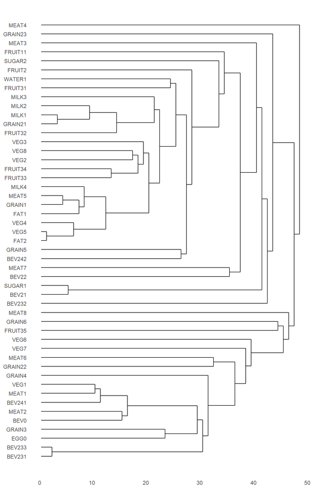

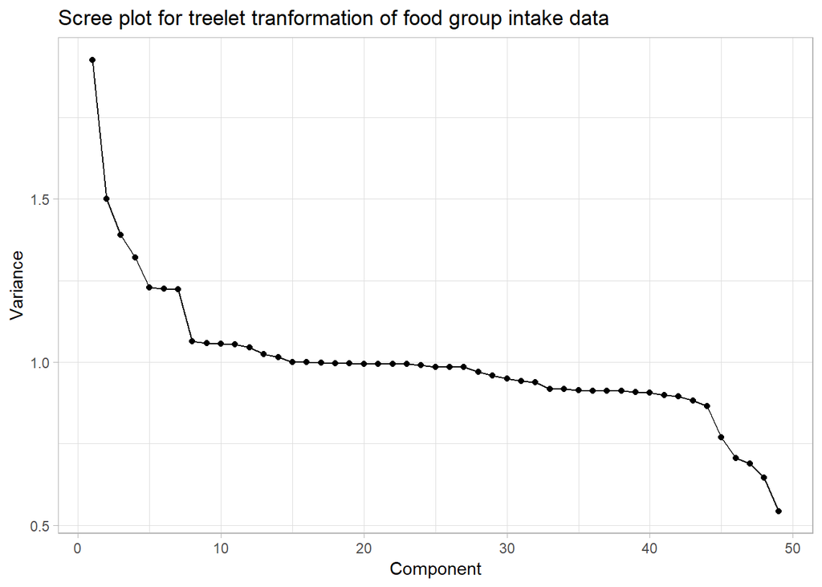

The scree plot indicates that it would be appropriate to retain 8 components, as beyond this point there is little incremental increase in variance explained with each additional component.

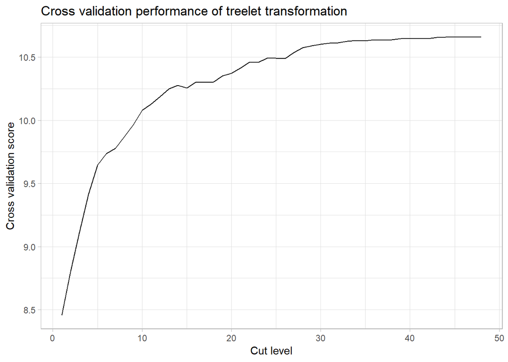

The cross validation plot indicates that a cut level of 25 would be appropriate, as there is little additional increase in score with increasing cut level beyond this point.

There was very little correlation among the TCs.

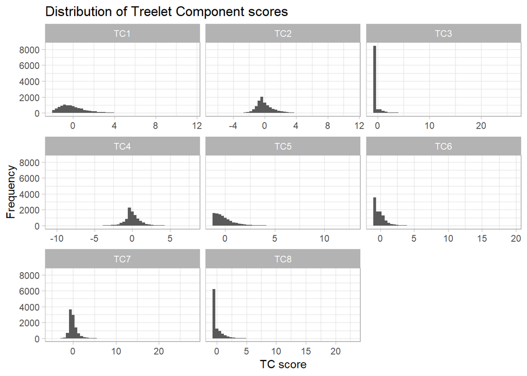

Correlation of TC scores

|  | TC1 | TC2 | TC3 | TC4 | TC5 | TC6 | TC7 | TC8 |
| --- | --- | --- | --- | --- | --- | --- | --- | --- |
| TC1 |  |  |  |  |  |  |  |  |
| TC2 | 0.01 |  |  |  |  |  |  |  |
| TC3 | 0.02 | -0.01 |  |  |  |  |  |  |
| TC4 | -0.02 | 0.03 | 0.05 |  |  |  |  |  |
| TC5 | -0.03 | -0.09 | 0.08 | 0.09 |  |  |  |  |
| TC6 | 0.04 | -0.01 | -0.03 | 0.07 | 0.05 |  |  |  |
| TC7 | 0.04 | 0.05 | -0.04 | -0.09 | -0.13 | -0.07 |  |  |
| TC8 | -0.04 | -0.03 | 0.05 | 0.01 | 0.08 | 0.04 | -0.02 |  |

Components TC1 and TC2 were broadly loaded but the others were sparse.

| Component | Non-zero scores |
| --- | --- |
| TC1 | 19 |
| TC2 | 17 |
| TC3 | 2 |
| TC4 | 7 |
| TC5 | 5 |
| TC6 | 2 |
| TC7 | 12 |
| TC8 | 2 |

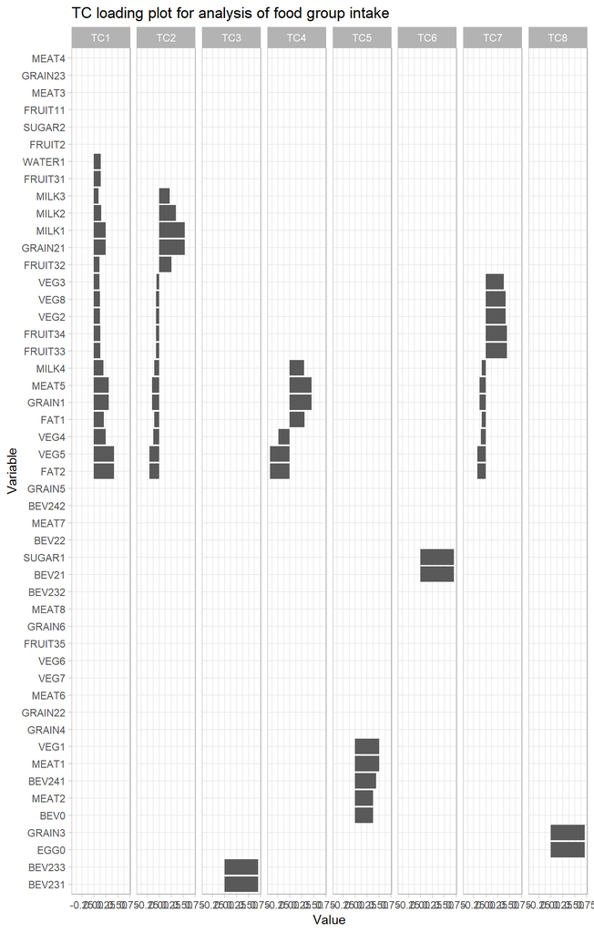

```r
ggplot(food_groups_loadings, aes(x = Variable, y = Value)) +
  facet_wrap(~Component, nrow = 1) +
  geom_bar(stat = "identity") +
  coord_flip() +
  theme_light() +
  ggtitle("TC loading plot for analysis of food group intake")
```

## Clinical attachment loss (CAL)

Associations between TCs and CAL were assessed using Beta regression.

```
##
## Call:
## betareg(formula = prop_CAL_sites3mm_beta ~ RIDAGEYR + RIAGENDR +
##     SMQ020 + diabetes + KCAL + TC1 + TC2 + TC3 + TC4 + TC5 + TC6 +
##     TC7 + TC8 | RIDAGEYR + RIAGENDR + SMQ020 + diabetes, data = nh)
##
## Standardized weighted residuals 2:
##     Min      1Q  Median      3Q     Max
## -4.1278 -0.4235  0.0608  0.5020  4.9914
##
## Coefficients (mean model with logit link):
##                Estimate Std. Error z value Pr(>|z|)
## (Intercept)  -1.416e+00  9.543e-02 -14.841  < 2e-16 ***
## RIDAGEYR      3.663e-02  9.719e-04  37.686  < 2e-16 ***
## RIAGENDR     -5.832e-01  2.836e-02 -20.567  < 2e-16 ***
## SMQ020       -5.370e-01  2.630e-02 -20.420  < 2e-16 ***
## diabetesTRUE  3.247e-01  3.523e-02   9.217  < 2e-16 ***
## KCAL          3.562e-06  1.797e-05   0.198  0.84290
## TC1          -1.089e-01  8.917e-03 -12.210  < 2e-16 ***
## TC2          -2.046e-03  9.623e-03  -0.213  0.83160
## TC3           1.843e-02  9.700e-03   1.900  0.05741 .
## TC4          -4.277e-03  9.998e-03  -0.428  0.66880
## TC5           4.522e-02  1.143e-02   3.957  7.6e-05 ***
## TC6           2.809e-02  1.058e-02   2.654  0.00794 **
## TC7          -7.497e-03  1.021e-02  -0.734  0.46286
## TC8           2.026e-03  1.104e-02   0.184  0.85438
##
## Phi coefficients (precision model with log link):
##                Estimate Std. Error z value Pr(>|z|)
## (Intercept)   0.3003445  0.0727401   4.129 3.64e-05 ***
## RIDAGEYR     -0.0123295  0.0009301 -13.256  < 2e-16 ***
## RIAGENDR      0.2530251  0.0268628   9.419  < 2e-16 ***
## SMQ020        0.3704453  0.0260554  14.218  < 2e-16 ***
## diabetesTRUE -0.1456771  0.0339191  -4.295 1.75e-05 ***
## ---
## Signif. codes:  0 '***' 0.001 '**' 0.01 '*' 0.05 '.' 0.1 ' ' 1
##
## Type of estimator: ML (maximum likelihood)
## Log-likelihood:  9599 on 19 Df
## Pseudo R-squared: 0.2042
## Number of iterations: 29 (BFGS) + 3 (Fisher scoring)
```

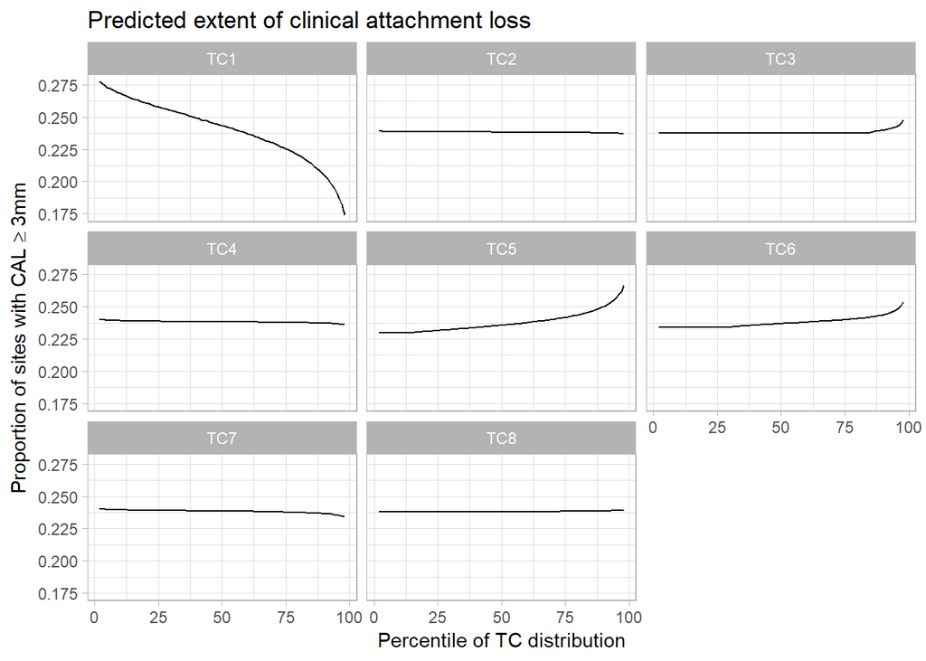